# Practical Machine Learning Course Project - prediction of exercise correctness based on movement data

Massabrasil

10th december 2017

```r
Sys.time()
```

```
## [1] "2017-12-18 21:21:48 -02"
```

## Introduction

We live in an age that means to collect large amound of data about specific observations such personal activities are availabe to average people - Using devices available for purchasing such as JawboneUp, NikeFuelBand, and Fitbitit (or further devices) and relatively inexpensive budget. We have available data collected on study that aimed to quantify movement of some volunteers, enthusiasts that have taken measures regularly and to analyze them,aiming to find clues for health improvement, by finding patterns.

A distinct aspect of this project is to focus the point people usually does not pay attention - instead of quantifying a particular activity they do, it focuses in QUALIFYING how well they do it.

This project used data from `accelerometers` on the `belt`, `forearm`, `arm`, and `dumbell` of 6 participants; they performed barbell lifts - correctly and incorrectly in 5 different ways.

More information is available from the [website](http://groupware.les.inf.puc-rio.br/har) (see details in the section on the ‘Weight Lifting Exercise Dataset’).

## Data

Data are made available, as below:

Training data: https://d396qusza40orc.cloudfront.net/predmachlearn/pml-training.csv.

Test data: https://d396qusza40orc.cloudfront.net/predmachlearn/pml-testing.csv.

These data were produced by mentioned project - http://groupware.les.inf.puc-rio.br/har.

As requested and understood by me, if I “… use the document you create for this class for any purpose please cite them as they have been very generous in allowing their data to be used for this kind of assignment”, I would also like to join to students of this courser - Practice Machine Learning in Coursera.org - to forward our appreciation for the project team for kindly sharing their document for the course, I encourage forthcoming fellows to follow and value such act of sharing and supportiveness among research community.

# Loading dataset

Using caret package, data are loaded - training and testing data:

```r
library(caret);
```

```r
set.seed(12345)

# downloads below were done once at the beginning and inhibited, from now on,
# execution will take files already downloaded locally.
#
# url_train <- "http://d396qusza40orc.cloudfront.net/predmachlearn/pml-training.csv"
# download.file(url_train,"pml-training.csv")
# trying URL 'http://d396qusza40orc.cloudfront.net/predmachlearn/pml-training.csv'
# Content type 'text/csv' length 12202745 bytes (11.6 MB)
# downloaded 11.6 MB
#
# url_test <- "http://d396qusza40orc.cloudfront.net/predmachlearn/pml-testing.csv"
# download.file(url_test,"pml-testing.csv")
# trying URL 'http://d396qusza40orc.cloudfront.net/predmachlearn/pml-testing.csv'
# Content type 'text/csv' length 15113 bytes (14 KB)
# downloaded 14 KB
#
setwd("C:/coursera/07 Practical Machine Learning/assignment/practicalmachinelearning")

pml_train <-read.csv("./pml-training.csv", header=TRUE)
dim(pml_train)
```

```
## [1] 19622   160
```

```r
pml_test <- read.csv("./pml-testing.csv", header=TRUE)
dim(pml_test)
```

```
## [1]  20 160
```

Except for the last column of both dataset, train and test, compare them and confirm they are the same in both.

# Ensure predictors are comparable in both dataset

```r
colnames_test <- colnames(pml_test)
colnames_train <- colnames(pml_train)
all.equal(colnames_train[1:length(colnames_train)-1],colnames_test[1:length(colnames_train)-1])
```

```
## [1] TRUE
```

In case dataset columns are equal, function above yields TRUE, otherwise we could stop at this point and go back working on them.

# Data cleansing

## Remove NA from data set

There are some columns that have value NA. Decision taken in this project was to get rid in both of those columns having 50% or more rows in training dataset.

```r
Perc50ofNA    <- sapply(pml_train, function(x) mean(is.na(x))) >= 0.50
pml_train <- pml_train[, Perc50ofNA==FALSE]
pml_test  <- pml_test[, Perc50ofNA==FALSE]
dim(pml_train)
```

```
## [1] 19622    93
```

```r
dim(pml_test)
```

```
## [1] 20 93
```

## Remove near zero variables

```r
nzv_pml_train <- nearZeroVar(pml_train, saveMetrics=TRUE)
pml_train <- pml_train[,nzv_pml_train$nzv==FALSE]
pml_test <- pml_test[,nzv_pml_train$nzv==FALSE]
dim(pml_train)
```

```
## [1] 19622    59
```

```r
dim(pml_test)
```

```
## [1] 20 59
```

## Remove columns non-candidate as predictor

At this point, we also can get rid of those columns as row/windows numbers, experiment individual alias, timestamps :

```r
pml_train <- pml_train[, -(1:7)]
pml_test <- pml_test[, -(1:7)]
dim(pml_train)
```

```
## [1] 19622    52
```

```r
dim(pml_test)
```

```
## [1] 20 52
```

# Data cleansing/slicing

## Split training dataset in one subset (training) and another (validation)

Because I want to be able to estimate the out-of-sample error, I randomly split the full training data (ptrain) into a smaller training set (ptrain1) and a validation set (ptrain2):

```r
inTrain <- createDataPartition(y=pml_train$classe, p=0.7, list=F);
pml_train_1 <- pml_train[inTrain, ];
pml_train_2 <- pml_train[-inTrain, ];
dim(pml_train_1)
```

```
## [1] 13737    52
```

```r
dim(pml_train_2)
```

```
## [1] 5885   52
```

# Modeling

Data were cleaned up, we are ready to proceed in modeling.

The kind of problem of this assignment is of classification. From this point, the task here is to enlist identified prediction methods and components involved.

Below we can find those gathered to meet this goal:

- decision tree (rpart)
- gradient boosting (gbm)
- random forest (rf)

## Cross validation

Cross validation was specified Using trainControl function, with fold number arbitrarily set to 5 folds, as a way to achieve balance between number of foldings and data subset size.

```r
# train control
trControl <- trainControl(method = "cv", number = 5, allowParallel=TRUE)
```

## setup of processing cluster

As attempt to speedup processing of train() with method “rf” (randon forest), advice from Len Gretsky was followed, setting up cluster in the session.

```r
library(parallel)
library(doParallel)
cluster <- makeCluster(detectCores() - 2)
# convention to leave 1 core for OS

registerDoParallel(cluster)
```

# Modeling

## Random Forest

### Training

```r
# build model

Sys.time()
```

```
## [1] "2017-12-18 21:22:12 -02"
```

```r
mod_rf <- train(classe~., method="rf", trControl=trControl,pml_train_1, verbose=FALSE)
Sys.time()
```

```
## [1] "2017-12-18 21:35:51 -02"
```

### Predicting

```r
predict_rf <- predict(mod_rf, pml_train_2)
```

### Confusion Matrix - accuracy

```r
cm_rf <- confusionMatrix(predict_rf, pml_train_2$classe)
cm_rf
```

```
## Confusion Matrix and Statistics
##
##           Reference
## Prediction    A    B    C    D    E
##          A 1670    9    0    0    0
##          B    4 1126   10    0    0
##          C    0    3 1012   11    1
##          D    0    0    4  953    4
##          E    0    1    0    0 1077
##
## Overall Statistics
##
##                Accuracy : 0.992
##                  95% CI : (0.9894, 0.9941)
##     No Information Rate : 0.2845
##     P-Value [Acc > NIR] : < 2.2e-16
##
##                   Kappa : 0.9899
##  Mcnemar's Test P-Value : NA
##
## Statistics by Class:
##
##                      Class: A Class: B Class: C Class: D Class: E
## Sensitivity            0.9976   0.9886   0.9864   0.9886   0.9954
## Specificity            0.9979   0.9971   0.9969   0.9984   0.9998
## Pos Pred Value         0.9946   0.9877   0.9854   0.9917   0.9991
## Neg Pred Value         0.9990   0.9973   0.9971   0.9978   0.9990
## Prevalence             0.2845   0.1935   0.1743   0.1638   0.1839
## Detection Rate         0.2838   0.1913   0.1720   0.1619   0.1830
## Detection Prevalence   0.2853   0.1937   0.1745   0.1633   0.1832
## Balanced Accuracy      0.9977   0.9928   0.9916   0.9935   0.9976
```

## Decision Tree

### Training / plotting

```r
mod_dt <- train(classe~., method="rpart", trControl=trControl, pml_train_1)
library(rattle)
```

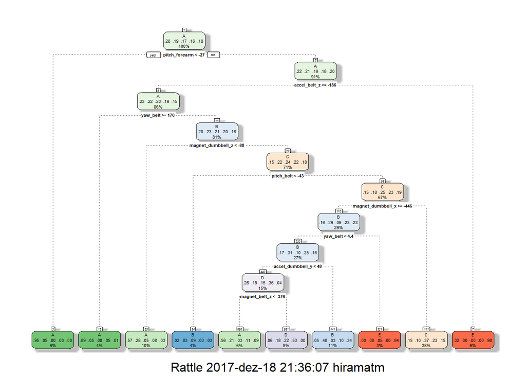

```r
fancyRpartPlot(mod_dt$finalModel)
```

### Predicting

```r
predict_dt <- predict(mod_dt, newdata=pml_train_2)
```

### Confusion Matrix - accuracy

```r
cm_dt <- confusionMatrix(predict_dt, pml_train_2$classe)
cm_dt
```

```
## Confusion Matrix and Statistics
##
##           Reference
## Prediction    A    B    C    D    E
##          A 1283  289   54   87   64
##          B   35  491   39   60  222
##          C  310  254  816  523  326
##          D   31  105  105  294    7
##          E   15    0   12    0  463
##
## Overall Statistics
##
##                Accuracy : 0.5687
##                  95% CI : (0.556, 0.5814)
##     No Information Rate : 0.2845
##     P-Value [Acc > NIR] : < 2.2e-16
##
##                   Kappa : 0.454
##  Mcnemar's Test P-Value : < 2.2e-16
##
## Statistics by Class:
##
##                      Class: A Class: B Class: C Class: D Class: E
## Sensitivity            0.7664  0.43108   0.7953  0.30498  0.42791
## Specificity            0.8827  0.92499   0.7092  0.94960  0.99438
## Pos Pred Value         0.7220  0.57969   0.3661  0.54244  0.94490
## Neg Pred Value         0.9048  0.87138   0.9426  0.87460  0.88526
## Prevalence             0.2845  0.19354   0.1743  0.16381  0.18386
## Detection Rate         0.2180  0.08343   0.1387  0.04996  0.07867
## Detection Prevalence   0.3020  0.14393   0.3788  0.09210  0.08326
## Balanced Accuracy      0.8246  0.67803   0.7523  0.62729  0.71114
```

## GBM (Generalized Boosted Regression)

### Training

```r
Sys.time()
```

```
## [1] "2017-12-18 21:36:13 -02"
```

```r
mod_gbm <- train(classe~., method="gbm", trControl=trControl, pml_train_1,verbose=FALSE)
Sys.time()
```

```
## [1] "2017-12-18 21:41:29 -02"
```

### Confusion Matrix - accuracy

```r
predict_gbm <- predict(mod_gbm, newdata=pml_train_2)
cm_gbm <- confusionMatrix(predict_gbm, pml_train_2$classe)
cm_gbm
```

```
## Confusion Matrix and Statistics
##
##           Reference
## Prediction    A    B    C    D    E
##          A 1647   49    0    0    2
##          B   17 1049   44    2   17
##          C    3   36  967   42    7
##          D    5    0   15  913   18
##          E    2    5    0    7 1038
##
## Overall Statistics
##
##                Accuracy : 0.954
##                  95% CI : (0.9483, 0.9592)
##     No Information Rate : 0.2845
##     P-Value [Acc > NIR] : < 2.2e-16
##
##                   Kappa : 0.9417
##  Mcnemar's Test P-Value : 1.078e-08
##
## Statistics by Class:
##
##                      Class: A Class: B Class: C Class: D Class: E
## Sensitivity            0.9839   0.9210   0.9425   0.9471   0.9593
## Specificity            0.9879   0.9831   0.9819   0.9923   0.9971
## Pos Pred Value         0.9700   0.9291   0.9166   0.9600   0.9867
## Neg Pred Value         0.9936   0.9811   0.9878   0.9897   0.9909
## Prevalence             0.2845   0.1935   0.1743   0.1638   0.1839
## Detection Rate         0.2799   0.1782   0.1643   0.1551   0.1764
## Detection Prevalence   0.2885   0.1918   0.1793   0.1616   0.1788
## Balanced Accuracy      0.9859   0.9521   0.9622   0.9697   0.9782
```

## Un-registering parallel processing cluster

```r
stopCluster(cluster)
registerDoSEQ()
```

# Conclusion

## Method with highest accuracy and prediction using testing dataset

Random Forest : 0.9920136

Decision Tree : 0.5687341

GBM : 0.9539507

Thus, the one with highest accuracy, i.e. Random Forest model, is applied to predict the 20 quiz results from testing dataset.

## Testing result

```r
predict_test <- predict(mod_rf, newdata=pml_test)
predict_test
```

```
##  [1] B A B A A E D B A A B C B A E E A B B B
## Levels: A B C D E
```

For the model chosen, expected out-of-sample error found was 1.0-0.9920136 = 0.0079864, i.e. 0.7986406 %.

(Report generated at 2017-12-18 21:41:32)